# Project Python Foundations: FoodHub Data Analysis

## **Exploratory Data Analysis (EDA)**

### Univariate Analysis

#### **Question 6:** Explore all the variables and provide observations on their distributions. (Generally, histograms, boxplots, countplots, etc. are used for univariate exploration.) [9 marks]

#### Observations on **Cuisine Type**:

- American cuisines are the most ordered cuisines by customers.
- Followed by Japanese in 2nd place, and Italian for 3rd place.
- The least ordered cuisine type is Vietnamese.

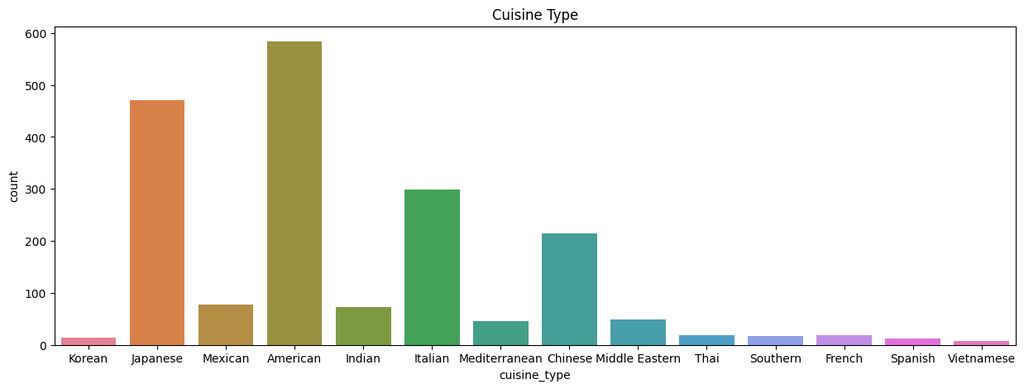

```python
# Create a countplot on Cuisine Type
sns.countplot(data=df,x='cuisine_type',hue='cuisine_type').set_title('Cuisine Type')
plt.gcf().set_size_inches(15, 5)
plt.show()
```

#### EDA on **Rating**:

```python
# Extract all information on 'Rating' where values are Null.
df.loc[df['rating'].isnull()]
```

|  | order_id | customer_id | restaurant_name | cuisine_type | cost_of_the_order | day_of_the_week | rating | food_preparation_time | delivery_time |
| --- | --- | --- | --- | --- | --- | --- | --- | --- | --- |
| 0 | 1477147 | 337525 | Hangawi | Korean | 30.75 | Weekend | NaN | 25 | 20 |
| 1 | 1477685 | 358141 | Blue Ribbon Sushi Izakaya | Japanese | 12.08 | Weekend | NaN | 25 | 23 |
| 6 | 1477894 | 157711 | The Meatball Shop | Italian | 6.07 | Weekend | NaN | 28 | 21 |
| 10 | 1477895 | 143926 | Big Wong Restaurant _¤¾Ñ¼ | Chinese | 5.92 | Weekday | NaN | 34 | 28 |
| 14 | 1478198 | 62667 | Lucky's Famous Burgers | American | 12.13 | Weekday | NaN | 23 | 30 |
| ... | ... | ... | ... | ... | ... | ... | ... | ... | ... |
| 1887 | 1476873 | 237616 | Shake Shack | American | 5.82 | Weekend | NaN | 26 | 30 |
| 1891 | 1476981 | 138586 | Shake Shack | American | 5.82 | Weekend | NaN | 22 | 28 |
| 1892 | 1477473 | 97838 | Han Dynasty | Chinese | 29.15 | Weekend | NaN | 29 | 21 |
| 1895 | 1477819 | 35309 | Blue Ribbon Sushi | Japanese | 25.22 | Weekday | NaN | 31 | 24 |
| 1897 | 1478056 | 120353 | Blue Ribbon Sushi | Japanese | 19.45 | Weekend | NaN | 28 | 24 |

736 rows × 9 columns

```python
# Fill missing ratings with -1 and then convert to integers
df['rating'] = df['rating'].fillna(-1).astype(int)
```

[figure not shown]

```python
sns.histplot(data=df,x='rating',hue='rating',hue_order=["5", "4", "3"]).set_title('Rating')

plt.show()
```

Observations on **Rating**:

- Nearly 40% or 736 of customers **did not provide** a rating (not shown here)
- Approx 30% or 588 of customers gave a rating of **5**
- Approx 20% or 386 of customers gave a rating of **4**
- Approx 10% or 188 of customers gave a rating of **3**

#### Observations on **Days of the week**

- Most orders are placed on the **weekend**.

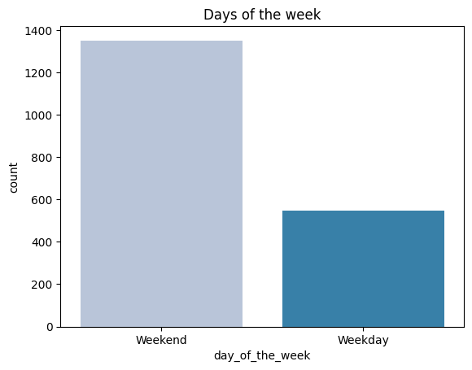

| day_of_the_week | count |
| --- | --- |
| Weekend | 1351 |
| Weekday | 547 |

**dtype:** int64

```python
sns.countplot(data=df,x='day_of_the_week',hue='day_of_the_week', palette='PuBu').set_title('Days of the week')
plt.show()

df['day_of_the_week'].value_counts()
```